# EDA of GapMinder DataSet

# 3.2) Five Num Summary Life Expectancy Region wise

```r
library(dplyr)
SouthAsia=filter(mydata, region=="South Asia")
fivenum(SouthAsia$life)
```

```
## [1]  7.045063 27.345157 32.647000 44.374110 79.500000
```

```r
fivenum(SouthAsia$population)
```

```
## [1] NA NA NA NA NA
```

```r
fivenum(SouthAsia$income)
```

```
## [1]   603.0   840.0  1020.0  1286.5 14408.0
```

```r
EastAsiaPacific = filter(mydata,region=="East Asia & Pacific")
fivenum(EastAsiaPacific$life)
```

```
## [1]  1.00000 28.94900 34.00000 57.49076 83.50000
```

```r
fivenum(EastAsiaPacific$population)
```

```
## [1] NA NA NA NA NA
```

```r
fivenum(EastAsiaPacific$income)
```

```
## [1]    363.0    873.0   1153.5   2557.5 134864.0
```

```r
EuropeCentralAsia=filter(mydata,region=="Europe & Central Asia")
fivenum(EuropeCentralAsia$life)
```

```
## [1]  3.98908 35.60000 41.74110 66.60000 84.10000
```

```r
fivenum(EuropeCentralAsia$population)
```

```
## [1] NA NA NA NA NA
```

```r
fivenum(EuropeCentralAsia$income)
```

```
## [1]   393  1427  2735  7387 96245
```

```r
MiddleEastNorthAfrica = filter(mydata,region=="Middle East & North Africa")
fivenum(MiddleEastNorthAfrica$life)
```

```
## [1]  1.50000 30.71320 32.30000 53.70766 82.40000
```

```r
fivenum(MiddleEastNorthAfrica$population)
```

```
## [1] NA NA NA NA NA
```

```r
fivenum(MiddleEastNorthAfrica$income)
```

```
## [1]    715.0   1082.0   1537.5   3939.0 182668.0
```

```r
America =filter(mydata,region=="America")
fivenum(America$life)
```

```
## [1]  9.690052 32.124000 35.373700 61.048460 81.700000
```

```r
fivenum(America$population)
```

```
## [1] NA NA NA NA NA
```

```r
fivenum(America$income)
```

```
## [1]   529.0  1277.5  2214.5  5461.5 53354.0
```

```r
SubSaharanAfrica = filter(mydata,region=="Sub-Saharan Africa")
fivenum(SubSaharanAfrica$life)
```

```
## [1]  4.00000 30.43680 32.40338 46.00000 79.64600
```

```r
fivenum(SubSaharanAfrica$population)
```

```
## [1] NA NA NA NA NA
```

```r
fivenum(SubSaharanAfrica$income)
```

```
## [1]   142   596   827  1323 40143
```

Before proceeding we must convert population to integer

```r
mydata$population <- as.integer(mydata$population)
str(mydata)
```

```
## 'data.frame':    41284 obs. of  6 variables:
##  $ Country   : Factor w/ 197 levels "Ãland","Afghanistan",..: 2 2 2 2 2 2 2 2 2 2 ...
##  $ Year      : int  1800 1801 1802 1803 1804 1805 1806 1807 1808 1809 ...
##  $ life      : num  28.2 28.2 28.2 28.2 28.2 ...
##  $ population: int  7490 1 1 1 1 1 1 1 1 1 ...
##  $ income    : num  603 603 603 603 603 603 603 603 603 603 ...
##  $ region    : Factor w/ 6 levels "America","East Asia & Pacific",..: 5 5 5 5 5 5 5 5 5 5 ...
```

filter & sort data

```r
library(dplyr)
```

filter data for 2014 only

```r
longevity <- mydata %>%
filter(Year == 2014 & !is.na(life)) %>%
select(Country, life, income, region)
```

```r
str(longevity)
```

```
## 'data.frame':    178 obs. of  4 variables:
##  $ Country: Factor w/ 197 levels "Ãland","Afghanistan",..: 2 3 4 5 6 7 8 9 11 12 ...
##  $ life   : num  56.9 75.9 76.4 84 60.7 ...
##  $ income : num  1877 10160 13179 44929 7546 ...
##  $ region : Factor w/ 6 levels "America","East Asia & Pacific",..: 5 3 4 3 6 1 1 3 2 3 ...
```

```r
# find the twenty high-income countries with the lowest life expectancy
high_income_short_life <- longevity %>%
arrange(desc(income)) %>%
arrange(life) %>%
head(20)
```

```r
head(high_income_short_life)
```

```
##         Country  life income             region
## 1       Lesotho 48.40   2494 Sub-Saharan Africa
## 2     Swaziland 51.10   6058 Sub-Saharan Africa
## 3 Guinea-Bissau 53.10   1363 Sub-Saharan Africa
## 4    Mozambique 56.30   1115 Sub-Saharan Africa
## 5   Afghanistan 56.91   1877         South Asia
## 6          Chad 57.40   2141 Sub-Saharan Africa
```

```r
# Find the 20 countries with the longest life expectancies and United States with its rank, if it lies outside the top 20
long_life <- longevity %>%
  arrange(desc(life)) %>%
  mutate(rank = c(1:178)) %>%
  filter(rank <= 20 | Country == "United States")
```

```r
long_life
```

```
##           Country life income                     region rank
## 1         Andorra 84.0  44929      Europe & Central Asia    1
## 2           Japan 83.4  35635        East Asia & Pacific    2
## 3         Iceland 82.8  41237      Europe & Central Asia    3
## 4     Switzerland 82.8  55776      Europe & Central Asia    4
## 5          Cyprus 82.4  29673      Europe & Central Asia    5
## 6          Israel 82.3  31180 Middle East & North Africa    6
## 7           Italy 82.1  33078      Europe & Central Asia    7
## 8           Malta 82.1  29508      Europe & Central Asia    8
## 9       Singapore 82.0  78958        East Asia & Pacific    9
## 10          Qatar 81.9 133563 Middle East & North Africa   10
## 11         Sweden 81.9  44029      Europe & Central Asia   11
## 12      Australia 81.8  43219        East Asia & Pacific   12
## 13         France 81.8  37218      Europe & Central Asia   13
## 14          Spain 81.7  32270      Europe & Central Asia   14
## 15         Canada 81.6  42817                    America   15
## 16         Norway 81.5  64020      Europe & Central Asia   16
## 17 United Kingdom 81.2  37614      Europe & Central Asia   17
## 18     Luxembourg 81.1  88203      Europe & Central Asia   18
## 19        Austria 80.9  43906      Europe & Central Asia   19
## 20        Germany 80.9  43444      Europe & Central Asia   20
## 21  United States 79.0  52118                    America   36
```

```r
longevity_summary <- mydata %>%
  filter(!is.na(life)) %>%
  group_by(Year) %>%
  summarize(Country = n(),
            max_life_expect = max(life),
            min_life_expect = min(life)) %>%
  mutate(range_life_expect = max_life_expect - min_life_expect) %>%
  arrange(desc(Year))
```

```r
longevity_summary
```

[output not shown]

## 4. Data Visualization:

```r
library(ggplot2)
```

# 4.1 Boxplot of life expectancy by region

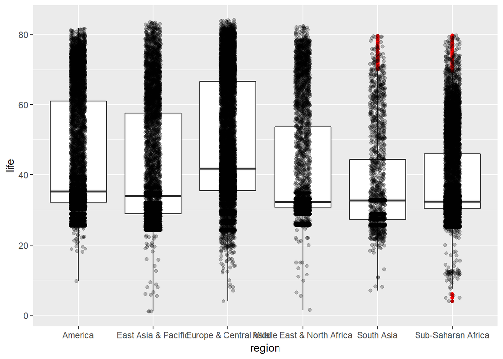

```r
library(ggplot2)
ggplot(mydata, aes(x = region, y = life)) +  geom_boxplot(outlier.colour = "red") +  geom_jitter(position = position_jitter(width = 0.1, height = 0), alpha = 1/4)
```

# 4.2 Histogram of life expectancy by region

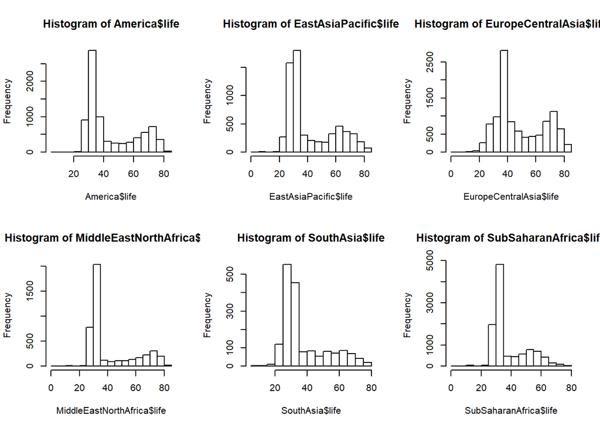

```r
library(ggplot2)
par(mfrow=c(2,3))
hist(America$life)
hist(EastAsiaPacific$life)
hist(EuropeCentralAsia$life)
hist(MiddleEastNorthAfrica$life)
hist(SouthAsia$life)
hist(SubSaharanAfrica$life)
```

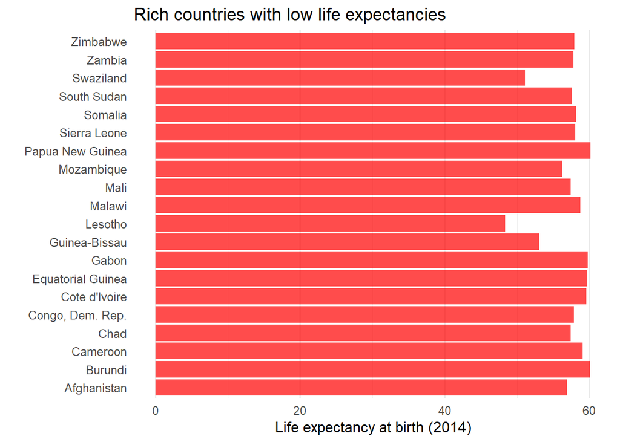

```r
ggplot(high_income_short_life, aes(x=Country, y=life)) +
  geom_bar(stat="identity", fill = "red", alpha = 0.7) +
  xlab("") +
  ylab("Life expectancy at birth (2014)") +
  ggtitle("Rich countries with low life expectancies") +
  theme_minimal(base_size = 12) +
  theme(panel.grid.major.y = element_blank(),
        panel.grid.minor.y = element_blank()) +
  coord_flip()
```

```r
j_country <- "France" # pick, but do not hard wire, an example
(j_dat <- mydata %>%
  filter(Country == j_country))
```

```
##     Country Year     life population income                region
## 1    France 1800 33.96717       6558   1803 Europe & Central Asia
## 2    France 1801 36.37465          1   1806 Europe & Central Asia
## 3    France 1802 34.37999          1   1810 Europe & Central Asia
## 4    France 1803 30.64262          1   1813 Europe & Central Asia
## 5    France 1804 29.38176          1   1817 Europe & Central Asia
## 6    France 1805 34.87632          1   1821 Europe & Central Asia
## 7    France 1806 35.00000          1   1824 Europe & Central Asia
## 8    France 1807 34.20000          1   1828 Europe & Central Asia
## 9    France 1808 34.50000          1   1832 Europe & Central Asia
## 10   France 1809 35.00000          1   1835 Europe & Central Asia
## 11   France 1810 37.40000       6937   1839 Europe & Central Asia
## 12   France 1811 36.10000          1   1842 Europe & Central Asia
## 13   France 1812 31.70000          1   1846 Europe & Central Asia
## 14   France 1813 31.20000          1   1850 Europe & Central Asia
```

[output cut: 202 more lines]

```r
str(mydata)
```

```
## 'data.frame':    41284 obs. of  6 variables:
##  $ Country   : Factor w/ 197 levels "Ãland","Afghanistan",..: 2 2 2 2 2 2 2 2 2 2 ...
##  $ Year      : int  1800 1801 1802 1803 1804 1805 1806 1807 1808 1809 ...
##  $ life      : num  28.2 28.2 28.2 28.2 28.2 ...
##  $ population: int  7490 1 1 1 1 1 1 1 1 1 ...
##  $ income    : num  603 603 603 603 603 603 603 603 603 603 ...
##  $ region    : Factor w/ 6 levels "America","East Asia & Pacific",..: 5 5 5 5 5 5 5 5 5 5 ...
```

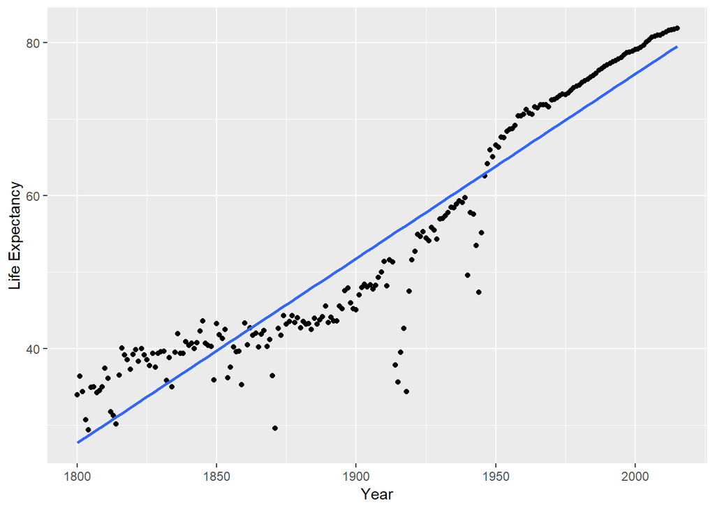

```r
p <- ggplot(j_dat, aes(x = Year, y = life))
p + geom_point() + geom_smooth(method = "lm", se = FALSE) + xlab("Year") +
  ylab("Life Expectancy")
```

This diagram shows Life Expectancy by Year

# fit regression

```r
j_fit <- lm(life ~ Year, j_dat)
coef(j_fit)
```

```
##  (Intercept)         Year
## -406.9460168    0.2414423
```

```r
j_fit <- lm(life ~ I(Year - 2014), j_dat)
coef(j_fit)
```

```
##    (Intercept) I(Year - 2014)
##     79.3188033      0.2414423
```

## 5. Hierarchical Clustering

```r
set.seed(786)
mydata <- read.csv('https://raw.githubusercontent.com/birdsarah/pydata-nc/master/tutorial/assets/gapminder.csv')
```

```r
str(mydata)
```

```
## 'data.frame':    41284 obs. of  6 variables:
##  $ Country   : Factor w/ 197 levels "Ãland","Afghanistan",..: 2 2 2 2 2 2 2 2 2 2 ...
##  $ Year      : int  1800 1801 1802 1803 1804 1805 1806 1807 1808 1809 ...
##  $ life      : num  28.2 28.2 28.2 28.2 28.2 ...
##  $ population: Factor w/ 15260 levels "","1,005,328,574",..: 7490 1 1 1 1 1 1 1 1 1 ...
##  $ income    : num  603 603 603 603 603 603 603 603 603 603 ...
##  $ region    : Factor w/ 6 levels "America","East Asia & Pacific",..: 5 5 5 5 5 5 5 5 5 5 ...
```

```r
feature_name <- c('country','year','life_expectancy','population','income','region')
colnames(mydata) <- feature_name
str(mydata)
```

```
## 'data.frame':    41284 obs. of  6 variables:
##  $ country        : Factor w/ 197 levels "Ãland","Afghanistan",..: 2 2 2 2 2 2 2 2 2 2 ...
##  $ year           : int  1800 1801 1802 1803 1804 1805 1806 1807 1808 1809 ...
##  $ life_expectancy: num  28.2 28.2 28.2 28.2 28.2 ...
##  $ population     : Factor w/ 15260 levels "","1,005,328,574",..: 7490 1 1 1 1 1 1 1 1 1 ...
##  $ income         : num  603 603 603 603 603 603 603 603 603 603 ...
##  $ region         : Factor w/ 6 levels "America","East Asia & Pacific",..: 5 5 5 5 5 5 5 5 5 5 ...
```

It’s advisable to gather some basic useful information about the dataset like its dimensions, data types and distribution, number of NAs etc. You will do so by using the str(), summary() and is.na() functions in R.

```r
summary(mydata)
```

```
##                 country           year      life_expectancy
##  Afghanistan        :  216   Min.   :1800   Min.   : 1.00
##  Albania            :  216   1st Qu.:1854   1st Qu.:31.00
##  Algeria            :  216   Median :1908   Median :35.12
##  Angola             :  216   Mean   :1907   Mean   :42.88
##  Antigua and Barbuda:  216   3rd Qu.:1962   3rd Qu.:55.60
##  Argentina          :  216   Max.   :2015   Max.   :84.10
##  (Other)            :39988
##    population        income                              region
##         :25817   Min.   :   142   America                   : 7961
##  121000 :    6   1st Qu.:   883   East Asia & Pacific       : 6256
##  14092  :    6   Median :  1450   Europe & Central Asia     :10468
##  1432000:    6   Mean   :  4571   Middle East & North Africa: 4309
##  229000 :    6   3rd Qu.:  3483   South Asia                : 1728
##  2574000:    6   Max.   :182668   Sub-Saharan Africa        :10562
##  (Other):15437   NA's   :2341
```

```r
any(is.na(mydata))
```

```
## [1] TRUE
```

# 5.1 Dealing with Missing Values

```r
# list rows of data that have missing values
mydata[!complete.cases(mydata),]
```

```
##                     country year life_expectancy population income
## 7164        Channel Islands 1950       68.516000     102235     NA
## 7165        Channel Islands 1951       68.714000     102965     NA
## 7166        Channel Islands 1952       69.090000     103653     NA
## 7167        Channel Islands 1953       69.425000    104,314     NA
## 7168        Channel Islands 1954       69.720000     104962     NA
## 7169        Channel Islands 1955       69.974000     105608     NA
## 7170        Channel Islands 1956       70.190000     106271     NA
## 7171        Channel Islands 1957       70.369000     106967     NA
## 7172        Channel Islands 1958       70.515000     107712     NA
## 7173        Channel Islands 1959       70.636000     108526     NA
## 7174        Channel Islands 1960       70.739000     109419     NA
## 7175        Channel Islands 1961       70.833000     110399     NA
## 7176        Channel Islands 1962       70.928000     111463     NA
## 7177        Channel Islands 1963       71.030000     112595     NA
```

[output cut: 4669 more lines]

```r
# create new dataset without missing data
EDAdata <- na.omit(mydata)
```

# using Imputation to deal with missing values

```r
#install.packages("Hmisc")
#install.packages("DMwR")
#install.packages("mice")
library(Hmisc)
library(DMwR)
library(mice)
library(mice)
miceMod <- mice(EDAdata[, !names(EDAdata) %in% "medv"], method="rf")  # perform mice imputation, based on random forests.
```

```
##
##   1   1
##   1   2
##   1   3
##   1   4
##   1   5
##   2   1
##   2   2
##   2   3
##   2   4
##   2   5
##   3   1
##   3   2
##   3   3
##   3   4
##   3   5
##   4   1
##   4   2
##   4   3
##   4   4
##   4   5
##   5   1
##   5   2
##   5   3
##   5   4
##   5   5
```

```r
miceOutput <- complete(miceMod)  # generate the completed data.
anyNA(miceOutput)
```

```
## [1] FALSE
```

```
#> FALSE
```

```r
#install.packages("VIM")
#install.packages(colorspace)
#install.packages(grid)
require(data.table)
library(colorspace)
library(VIM)
```

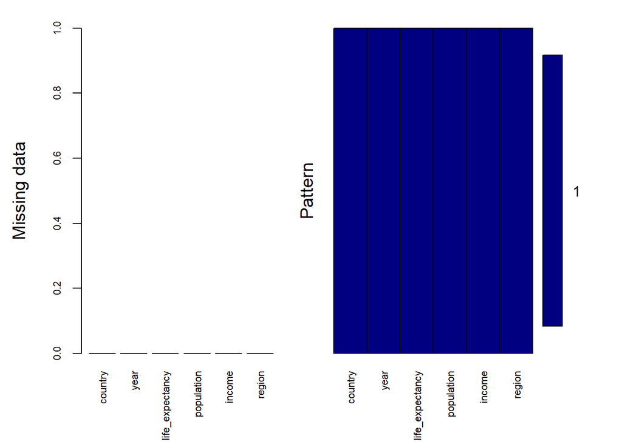

```
##
##  Variables sorted by number of missings:
##         Variable Count
##          country     0
##             year     0
##  life_expectancy     0
##       population     0
##           income     0
##           region     0
```

```r
mice_plot <- aggr(EDAdata, col=c('navyblue','yellow'),
numbers=TRUE, sortVars=TRUE,
labels=names(EDAdata), cex.axis=.7,
gap=3, ylab=c("Missing data","Pattern"))
```

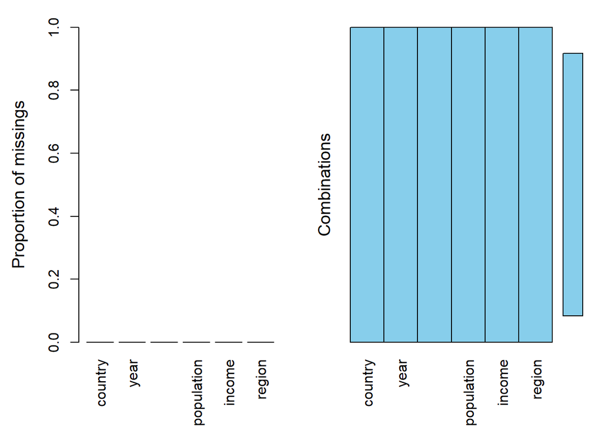

```r
aggr(EDAdata)
```

# 5.2 K-Means Clustering

```r
set.seed(20)
clusters <- kmeans(EDAdata[,2:3], 5)
# Save the cluster number in the dataset as column 'Borough'
EDAdata$country <- as.factor(clusters$cluster)

str(clusters)
```

```
## List of 9
##  $ cluster     : Named int [1:38943] 3 3 3 3 3 3 3 3 3 3 ...
##   ..- attr(*, "names")= chr [1:38943] "1" "2" "3" "4" ...
##  $ centers     : num [1:5, 1:2] 1993 1866 1822 1911 1952 ...
##   ..- attr(*, "dimnames")=List of 2
##   .. ..$ : chr [1:5] "1" "2" "3" "4" ...
##   .. ..$ : chr [1:2] "year" "life_expectancy"
##  $ totss       : num 1.62e+08
##  $ withinss    : num [1:5] 1907271 1533742 1399642 1805136 1936216
##  $ tot.withinss: num 8582008
##  $ betweenss   : num 1.53e+08
##  $ size        : int [1:5] 7978 8087 7900 7983 6995
##  $ iter        : int 2
##  $ ifault      : int 4
##  - attr(*, "class")= chr "kmeans"
```

no missing values

```r
any(is.na(EDAdata))
```

```
## [1] FALSE
```

```r
Country <- as.numeric(EDAdata$country)
Year <- as.numeric(EDAdata$year)
Income <- as.numeric(EDAdata$income)
life_exp <- as.numeric(EDAdata$life_expectancy)
Region <- as.numeric((EDAdata$region))
Population <- as.numeric(EDAdata$population)
```

```r
str(EDAdata)
```

```
## 'data.frame':    38943 obs. of  6 variables:
##  $ country        : Factor w/ 5 levels "1","2","3","4",..: 3 3 3 3 3 3 3 3 3 3 ...
##  $ year           : int  1800 1801 1802 1803 1804 1805 1806 1807 1808 1809 ...
##  $ life_expectancy: num  28.2 28.2 28.2 28.2 28.2 ...
##  $ population     : Factor w/ 15260 levels "","1,005,328,574",..: 7490 1 1 1 1 1 1 1 1 1 ...
##  $ income         : num  603 603 603 603 603 603 603 603 603 603 ...
##  $ region         : Factor w/ 6 levels "America","East Asia & Pacific",..: 5 5 5 5 5 5 5 5 5 5 ...
##  - attr(*, "na.action")= 'omit' Named int  7164 7165 7166 7167 7168 7169 7170 7171 7172 7173 ...
##   ..- attr(*, "names")= chr  "7164" "7165" "7166" "7167" ...
```

```r
EDAnew <- data.frame(Year,life_exp,Region,Income,Country,Population)
```

```r
str(EDAnew)
```

```
## 'data.frame':    38943 obs. of  6 variables:
##  $ Year      : num  1800 1801 1802 1803 1804 ...
##  $ life_exp  : num  28.2 28.2 28.2 28.2 28.2 ...
##  $ Region    : num  5 5 5 5 5 5 5 5 5 5 ...
##  $ Income    : num  603 603 603 603 603 603 603 603 603 603 ...
##  $ Country   : num  3 3 3 3 3 3 3 3 3 3 ...
##  $ Population: num  7490 1 1 1 1 1 1 1 1 1 ...
```

# life expectancy by region

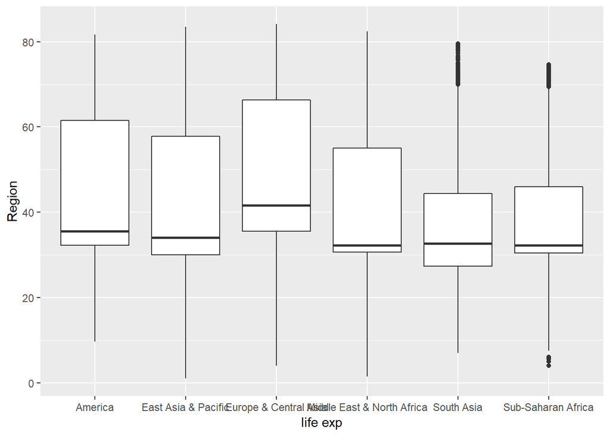

```r
ggplot(EDAnew,
    aes_string(y=EDAdata$life_expectancy,x=as.factor(EDAdata$region))) +
    geom_boxplot() +
    xlab('life exp') +
    ylab('Region')
```

```r
EDAnew_df <- EDAnew %>%
filter(Year == 2014 & !is.na(life_exp)) %>%
select( life_exp, Country,Income)
```

```r
Lifexp_df <- as.data.frame(scale(EDAnew_df))
summary(Lifexp_df)
```

```
##     life_exp          Country        Income
##  Min.   :-2.9156   Min.   : NA   Min.   :-0.8594
##  1st Qu.:-0.8159   1st Qu.: NA   1st Qu.:-0.7039
##  Median : 0.2245   Median : NA   Median :-0.3223
##  Mean   : 0.0000   Mean   :NaN   Mean   : 0.0000
##  3rd Qu.: 0.7983   3rd Qu.: NA   3rd Qu.: 0.3170
##  Max.   : 1.5739   Max.   : NA   Max.   : 5.9460
##                    NA's   :178
```

```r
dist_mat <- dist(Lifexp_df, method = 'euclidean')
```

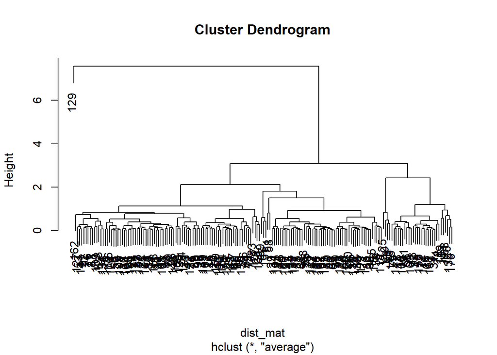

```r
hclust_avg <- hclust(dist_mat, method = 'average')
plot(hclust_avg)
```

```r
cut_avg <- cutree(hclust_avg, k = 3)
```

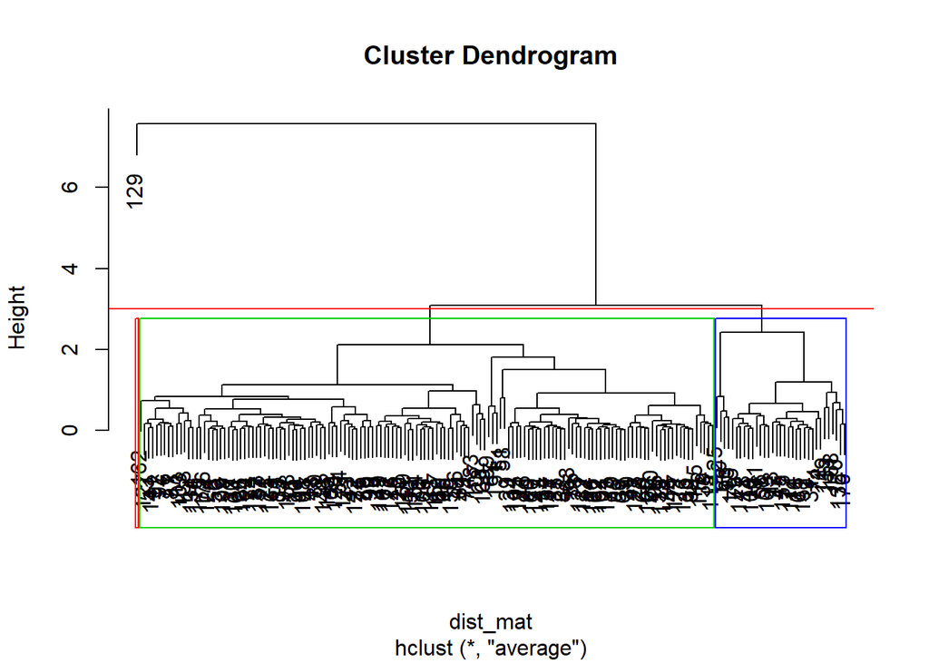

```r
plot(hclust_avg)
rect.hclust(hclust_avg , k = 3, border = 2:6)
abline(h = 3, col = 'red')
```

```r
#install.packages("dendextend")
suppressPackageStartupMessages(library(dendextend))
```

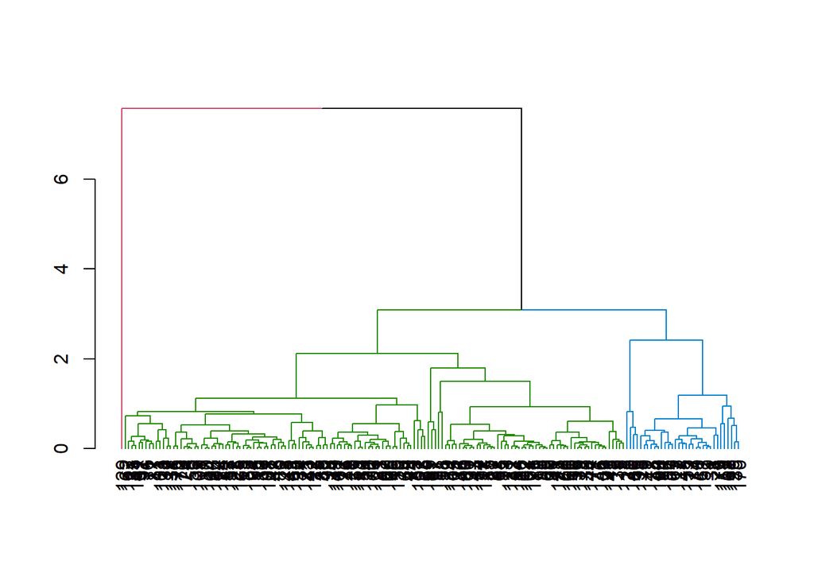

```r
avg_dend_obj <- as.dendrogram(hclust_avg)
avg_col_dend <- color_branches(avg_dend_obj, h = 3)
plot(avg_col_dend)
```